# Meropenem Target Attainment in Adults

# Introduction

- “Population Pharmacokinetic Analysis and Dosing Regimen Optimization of Meropenem in Adult Patients”
  - Li et al. J Clin Pharmacol 2006
- Meropenem is broad-spectrum carbapenem antibiotic
  - Efficacy related to time above MIC
- IV dosing every 8 hours by infusion or bolus
  - bolus over 3 to 5 minutes
  - infusion over 15 to 30 minutes
- Authors are interested in seeing if a longer infusion duration can increase time above MIC
- In this vignette, we’ll try to look at probability of target attainment for different infusion times and different MIC values

# Packages

```r
source("libPaths.R")
library(mrgsolve)
library(dmutate)
library(magrittr)
library(dplyr)
library(readr)

a <- config::get()
source(a$functions)
knitr_config()

set.seed(11000011)
```

# Load the `meropenem` model

```r
mod <- mread("meropenem", a$mero_project)
mod
```

```
.
.
. -------- mrgsolve model object (unix) --------
.   Project: /Users/kyleb/git/metrumresearchgroup/lvl2-workshop/model
.   source:        meropenem.cpp
.   shared object: meropenem-so-119483b7d59e9
.
.   compile date:
.   Time:          start: 0 end: 8 delta: 0.1
.   >              add: <none>
.   >              tscale: 1
.
.   Compartments:  CENT PERIPH [2]
.   Parameters:    WT CLCR AGE THETA1 THETA2 THETA3
.   >              THETA4 THETA5 THETA6 THETA7 THETA8 THETA9 [12]
.   Omega:         4x4
.   Sigma:         1x1
.
.   Solver:        atol: 1e-08 rtol: 1e-08
.   >              maxsteps: 2000 hmin: 0 hmax: 0
```

- The model was obtained from DDMoRe model repository
- http://repository.ddmore.foundation/model/DDMODEL00000213
- We took the model code as-is

```r
blocks(mod, MAIN)
```

```
.
. Model file: meropenem.cpp
.
. $MAIN
. double TVCL =    THETA1;
. double TVV1 =    THETA2;
. double TVQ  =    THETA3;
. double TVV2 =    THETA4;
. double CL_AGE =  THETA5;
. double V1_WT =   THETA6;
. double RUV_PROP =    THETA7;
. double RUV_ADD =    THETA8;
. double CL_CLCR = THETA9;
. double LOGTWT = log((WT/70));
. double LOGTAGE = log((AGE/35));
. double LOGTCLCR = log((CLCR/83));
. double MU_1 = log(TVCL) + CL_AGE * LOGTAGE + CL_CLCR * LOGTCLCR;
. double CL =  exp(MU_1 +  ETA(1)) ;
. double MU_2 = log(TVV1) + V1_WT * LOGTWT;
. double V1 =  exp(MU_2 +  ETA(2)) ;
. double MU_3 = log(TVQ);
. double Q =  exp(MU_3 +  ETA(3)) ;
. double MU_4 = log(TVV2);
. double V2 =  exp(MU_4 +  ETA(4));
```

- The covariates are: WT, AGE, CLCR

# Read in the meropenem data set

```r
data <-
  read_csv(a$mero_datafile,na='.')  %>%
  mutate(CMT=1, DUR = round(AMT/RATE,1))
```

- Infusion durations of 0.5 and 3 hours
- 79 total subjects

```r
data %>% filter(EVID==1) %>% count(DUR)
```

```
. # A tibble: 2 x 2
.     DUR     n
.   <dbl> <int>
. 1   0.5    40
. 2   3.0    39
```

What do we need?

- 1 g Q8h, duration 0.5, 1, 2, 3 hr
- Time > mic at ss (40 <= time <= 48)
- N=100 simulated sets of 79 patients (presumably the original population)

First, get the population set up

- From the publication, it it appears they simulated the studied patients 100 times
- We don’t quite have all the information we need here. For now, I’m going to re-sample 7900 patients from the original data set and simulate some of the remaining covariates
- Re-sample our population

```r
ids <- 1:7900

id <- distinct(data, ID, WT, CLCR, AGE) %>% ungroup

set.seed(11020)
id <- sample_n(id, max(ids), replace=TRUE) %>% mutate(ID = 1:n())
```

- We need to simulate some covariates here

```r
count(data, CLCR)
```

```
. # A tibble: 1 x 2
.    CLCR     n
.   <int> <int>
. 1    83   632
```

- Simulate `SCR` and `SEX`

```r
cov1 <- covset(SCR[0.4,6.9] ~ rnorm(1,0.8), SEX ~ rbinomial(0.95))

id %<>% mutate_random(cov1)
```

- Then calculate `CLCR`

```r
id %<>% mutate(CLCR = 0.85^(SEX==1)*(140-AGE)*WT/(SCR*72))
```

Make a dosing data frame

- For this, the authors only consider the 1g Q8H dose

```r
durations <- c(0.5, 1, 2, 3)

data <- expand.ev(amt = 1000, ii = 8, addl = 5,
                  ID = ids, dur = durations)

data <- mutate(data,
               ID = rep(ids, times = length(durations)),
               rate = amt/dur)

data <- left_join(data,id) %>% mutate(ID0 = ID, ID = 1:n())
```

- Create a `tgrid` object covering 40 to 48 hours
- It’s usually worth doing this … getting only the times that you really want to analyze

```r
des <- tgrid(0,8,0.1) + 5*8

stime(des)
```

```
.  [1] 40.0 40.1 40.2 40.3 40.4 40.5 40.6 40.7 40.8 40.9 41.0 41.1 41.2 41.3
. [15] 41.4 41.5 41.6 41.7 41.8 41.9 42.0 42.1 42.2 42.3 42.4 42.5 42.6 42.7
. [29] 42.8 42.9 43.0 43.1 43.2 43.3 43.4 43.5 43.6 43.7 43.8 43.9 44.0 44.1
. [43] 44.2 44.3 44.4 44.5 44.6 44.7 44.8 44.9 45.0 45.1 45.2 45.3 45.4 45.5
. [57] 45.6 45.7 45.8 45.9 46.0 46.1 46.2 46.3 46.4 46.5 46.6 46.7 46.8 46.9
. [71] 47.0 47.1 47.2 47.3 47.4 47.5 47.6 47.7 47.8 47.9 48.0
```

# Simulate from our data set

```r
out <-
  mod %>%
  data_set(data) %>% carry_out(dur) %>%
  mrgsim(tgrid = des, obsonly = TRUE)
```

# Work ou the code to summarize for a single `MIC`

- Summarize for `MIC==4`
- Subtract 40 from time
- group by `ID` and `dur`
- Calculate fraction of the interval above the `MIC`

```r
mic <- 4
sum <-
  out %>%
  mutate(time = time - 40) %>%
  group_by(ID,dur) %>%
  mutate(TMIC = first(time[Y < mic & time > 0.5 ])) %>%
  mutate(fmic = TMIC/8, fmic = ifelse(is.na(fmic),1,fmic)) %>%
  ungroup %>%
  distinct(ID,dur,fmic) %>%
  group_by(dur) %>%
  summarise(PR = mean(fmic >= 0.4))
sum
```

```
. # A tibble: 4 x 2
.     dur        PR
.   <dbl>     <dbl>
. 1   0.5 0.6648101
. 2   1.0 0.7173418
. 3   2.0 0.8454430
. 4   3.0 0.9684810
```

# Write come code to analyze all `MIC` of interest

```r
mic <- c(0.064, 0.128, 0.256, 0.512,
         1, 2, 4, 8, 16, 32, 64)
```

- Take the above code and wrap in a function
- Be sure to save the value for `mic` as well as the duration

```r
smry <- function(mic, out) {
  out %>%
  mutate(time = time - 40) %>%
  group_by(ID,dur) %>%
  mutate(TMIC = first(time[Y < mic & time > 0.5 ])) %>%
  mutate(fmic = TMIC/8, fmic = ifelse(is.na(fmic),1,fmic)) %>%
  ungroup %>%
  distinct(ID,dur,fmic) %>%
  group_by(dur) %>%
  summarise(PR = mean(fmic >= 0.4)) %>%
  mutate(mic = mic)
}
```

## Summarize by different `MIC`

```r
sum <- parallel::mclapply(mic, mc.cores = 8, smry, out = out)
sum <- bind_rows(sum)
```

# Plot the results

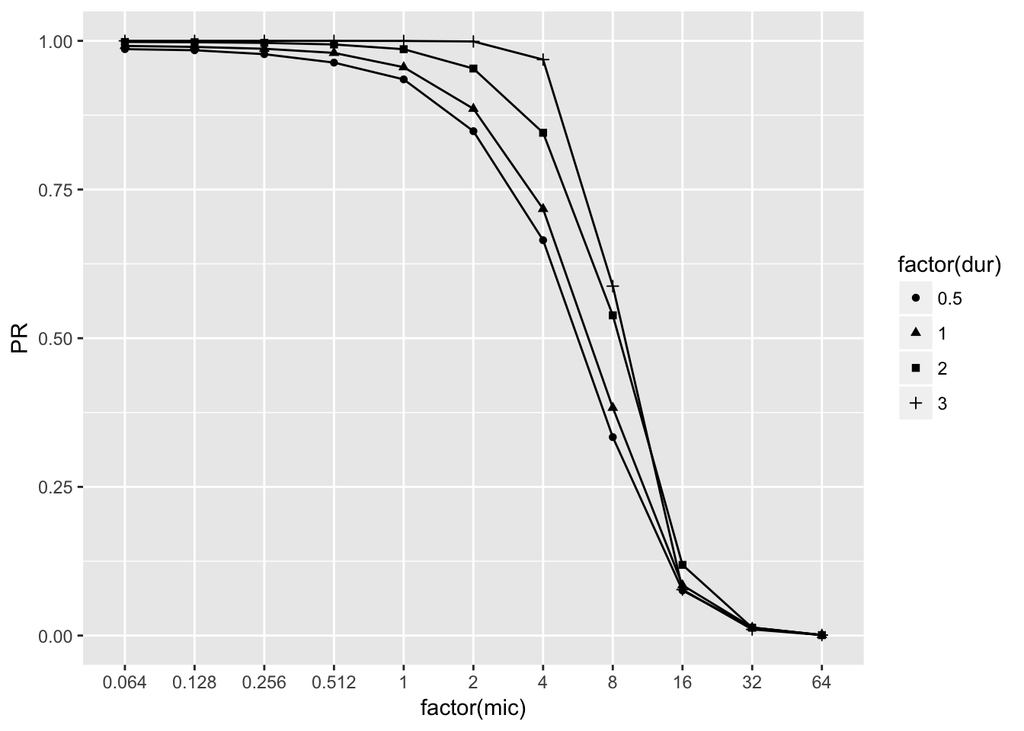

```r
ggplot(data = sum, aes(factor(mic), PR, group = dur, shape = factor(dur))) +
  geom_line() + geom_point()
```